# Geospatial Risk HW

Charlie Huemmler

2022-10-27

```r
knitr::opts_chunk$set(


  # hides warnings (e.g. WARNING: your code sucks)
  warning=FALSE,

  # hides messages (e.g. doesn't show the results of print("my code sucks"))
  message=FALSE,
  results='hide'

  )
```

```r
river <- area_water('PA', county = 'Philadelphia', progress_bar = FALSE) %>%
  st_as_sf()%>%
  st_transform(crs=2272) %>% filter(AWATER > 50000) %>% st_buffer(100)

phltract <- get_acs(state = 'PA', county = 'Philadelphia',
                    geography = 'tract', variables=c("B01001_001E"),
                    geometry = T, progress_bar = FALSE)

philly <- phltract %>% st_transform(crs = 2272) %>% st_union()


query <- paste("SELECT * FROM public_cases_fc",
               "WHERE service_name = 'Abandoned Vehicle'")

abandoned <- get_carto(query, format = "csv") %>%
  subset(select = -c(the_geom, cartodb_id, the_geom_webmercator))

abandonedsf <- abandoned %>% filter(!lon %>% is.na()) %>%
  st_as_sf(coords = c("lon","lat"),crs = 'NAD83') %>% st_crop(y = st_bbox(phltract)) %>%
  st_transform(crs = 2272) %>%
  mutate(year = requested_datetime %>% as.Date() %>% year())



ab2017 <- abandonedsf %>% filter(year == 2017) %>% mutate(Legend = 'abandoned_vehicles') %>% dplyr::select(Legend)
```

This geospatial prediction model attempts to predict the latent risk of abandoned vehicles in Philadelphia, PA. Because a vehicle being abandoned is a relatively rare event, and can take place anywhere, being able to predict the likelihood of a vehicle being abandoned everywhere is quite powerful.

The target variable in the model is a count of abandoned vehicle 311 reports within a set unit of space. As the data set is crowd-sourced from user submissions, it is not a perfect proxy for actual abandoned vehicles, as some vehicles go unreported and a single instance of an abandoned vehicle can receive multiple reports.

Reports to 311 face selection bias for numerous reasons. Instances of abandoned vehicles could be not reported if they are in an location people rarely observe, or if those that do observe the vehicles don’t use 311 or know an abandoned vehicle is a reportable offence. Furthermore, trust in the 311 system wains when city agencies are slow to respond to reports.

Due to the data being crowd-sourced and not recorded by a city agency, selection bias compounding due to the agency’s resource allocation is not a factor. Still, being able to predict where the events will occur will be helpful for city agencies in cleanup and surveillance.

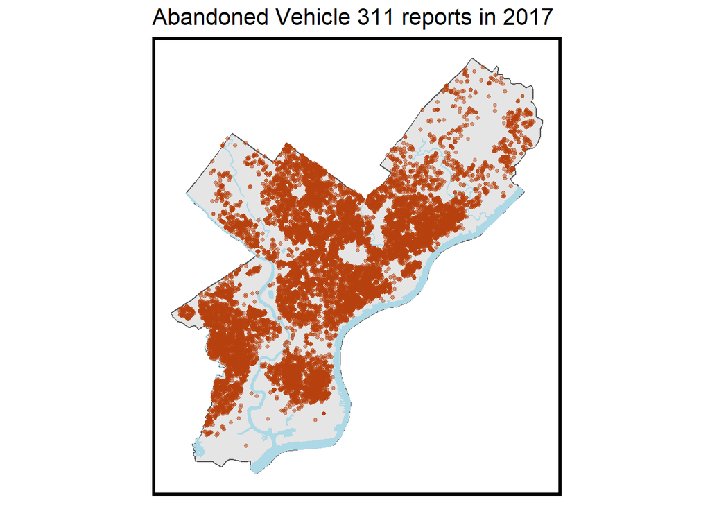

```r
ggplot()+
  geom_sf(data = philly)+
  geom_sf(data = river , color = NA, fill = 'lightblue')+
  geom_sf(data = ab2017, color = '#b7410e', size = 1, alpha = .5, shape = 19)+
  mapTheme()+
  labs(title = 'Abandoned Vehicle 311 reports in 2017')
```

We overlaid a grid of 500 feet by 500 feet squares over Philadelphia to have a standardized spatial unit of analysis by which to compare our variables.

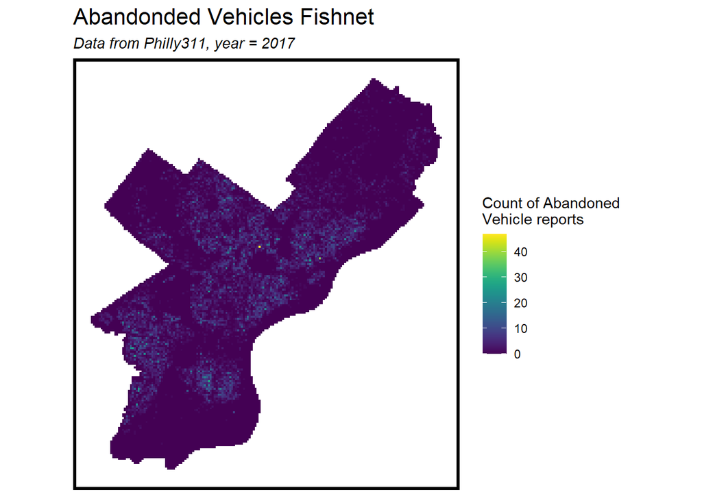

```r
#make fishnet
fishnet <-
  st_make_grid(philly, cellsize = 500) %>%
  st_sf() %>%
  mutate(uniqueID = rownames(.))

phillynet <- fishnet[philly,]

abv_net <-
  dplyr::select(ab2017) %>%
  mutate(countabv = 1) %>%
  aggregate(., phillynet, sum) %>%
  mutate(countabv = replace_na(countabv, 0),
         uniqueID = rownames(.))

#dept var fishnet
ggplot() +
  geom_sf(data = abv_net, aes(fill = countabv), color = NA)+
  scale_fill_viridis() +
  labs(title = "Abandonded Vehicles Fishnet", subtitle = 'Data from Philly311, year = 2017', fill = 'Count of Abandoned \nVehicle reports') +
  mapTheme()
```

To predict latent risk of abandoned vehicle dumping, we bring in numerous risk factors to append to our fishnet.

```r
#add features for vacant lots,


landuse <- read_sf("C:/Users/cchue/Documents/GIS/PhillyData/Land_Use.shp") %>%
  st_transform(crs = 2272)

vacantlots <- landuse %>% filter(C_DIG2 == 91)
vacantlotpoint <- vacantlots %>% st_centroid() %>% mutate(Legend = 'vacant_plots') %>% dplyr::select(Legend)




#illegal dumps
query <- paste("SELECT * FROM public_cases_fc",
               "WHERE service_name = 'Illegal Dumping'")

dumps <- get_carto(query, format = "csv") %>%
  subset(select = -c(the_geom, cartodb_id, the_geom_webmercator))

dumpsf <- dumps %>% filter(!lon %>% is.na()) %>%
  st_as_sf(coords = c("lon","lat"),crs = 'NAD83') %>% st_crop(y = st_bbox(phltract)) %>%
  st_transform(crs = 2272) %>%
  mutate(year = requested_datetime %>% as.Date() %>% year())

dump2017 <- dumpsf %>% filter(year == 2017) %>% mutate(Legend = 'illegal_dumping') %>% dplyr::select(Legend)

#fire and police stations
firedepts <- read_sf("C:/Users/cchue/Documents/GIS/PhillyData/firedept.shp") %>%
  st_transform(crs = 2272) %>% mutate(Legend = 'fire_stations') %>% dplyr::select(Legend)

police_stations<- read_sf("C:/Users/cchue/Documents/GIS/PhillyData/policefields.shp") %>%
  st_transform(crs = 2272)


#police districts
police_districts<- read_sf("C:/Users/cchue/Documents/GIS/PhillyData/policedistricts.shp") %>%
  st_transform(crs = 2272) %>%
  mutate(DISTRICT_ = `DISTRICT_` %>% as.character())

nhoods <- read_sf("C:/Users/cchue/Documents/GIS/PhillyData/Neighborhoods_Philadelphia.shp") %>%
  st_transform(crs = 2272)

#dist from bus routes

septaroutes <- readOGR("C:/Users/cchue/Documents/GIS/Transit/transitshp", layer = "busroutes2021", verbose = T) %>%
  st_as_sf() %>%
  st_transform(crs = 2272)

septaroutephl <- septaroutes %>% st_intersection(philly, .) %>% st_union()

#treeees
trees <- read_sf("C:/Users/cchue/Documents/GIS/PhillyData/treeinv.shp") %>%
  st_transform(crs = 2272) %>% mutate(Legend = 'trees') %>% dplyr::select(Legend)
```

```r
vars_net <-
  bind_rows(ab2017, vacantlotpoint, dump2017, trees) %>%
  st_join(., phillynet, join=st_within) %>%
  st_drop_geometry() %>%
  group_by(uniqueID, Legend) %>%
  summarize(count = n()) %>%
  full_join(phillynet) %>%
  spread(Legend, count, fill=0) %>%
  st_sf() %>%
  dplyr::select(-`<NA>`) %>%
  na.omit() %>%
  ungroup()

vars_net <- vars_net %>%
  mutate(fire_station_dist =
      nn_function(st_coordinates(st_centroid(vars_net)), st_coordinates(firedepts), 1))


vars_net <- vars_net %>%
  mutate(bus_route_dist = st_distance(st_centroid(vars_net), septaroutephl) %>%
           as.numeric())



final_net <-
  st_centroid(vars_net) %>%
  st_join(dplyr::select(police_districts, DISTRICT_)) %>%
  st_join(dplyr::select(nhoods, NAME)) %>%
  st_drop_geometry() %>%
  left_join(dplyr::select(vars_net, uniqueID)) %>%
  st_sf() %>%
  mutate(cvID = sample(round(nrow(vars_net) / 96), size=nrow(vars_net), replace = TRUE)) %>%
  na.omit() %>%
  rename('Police District' = DISTRICT_)



vars_net.long <-
  gather(final_net, Variable, value, -geometry, -uniqueID, -cvID)
```

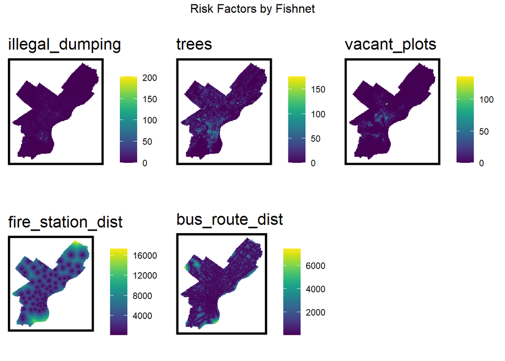

```r
##multplot
vars <- unique(vars_net.long$Variable)
vars <- vars[!vars %in% c('abandoned_vehicles', 'Police District', 'NAME')]

mapList <- list()
for(i in vars){
  mapList[[i]] <-
    ggplot() +
    geom_sf(data = filter(vars_net.long, Variable == i), aes(fill=as.numeric(value)), colour=NA) +
    scale_fill_viridis(name="") +
    labs(title=i) +
    mapTheme()}

do.call(grid.arrange, c(mapList, ncol=3, top="Risk Factors by Fishnet"))
```

The risk factors we include in the fishnet are:

- Amount of Illegal Dumping 311 reports in 2017.
- Number of individual trees recorded in the Parks and Rec tree inventory.
- Amount of vacant lot land uses.
- Distance to nearest fire station.
- Distance to nearest SEPTA bus line.

We also bring in neighborhood and police district boundaries for spatial LOGO analysis later.

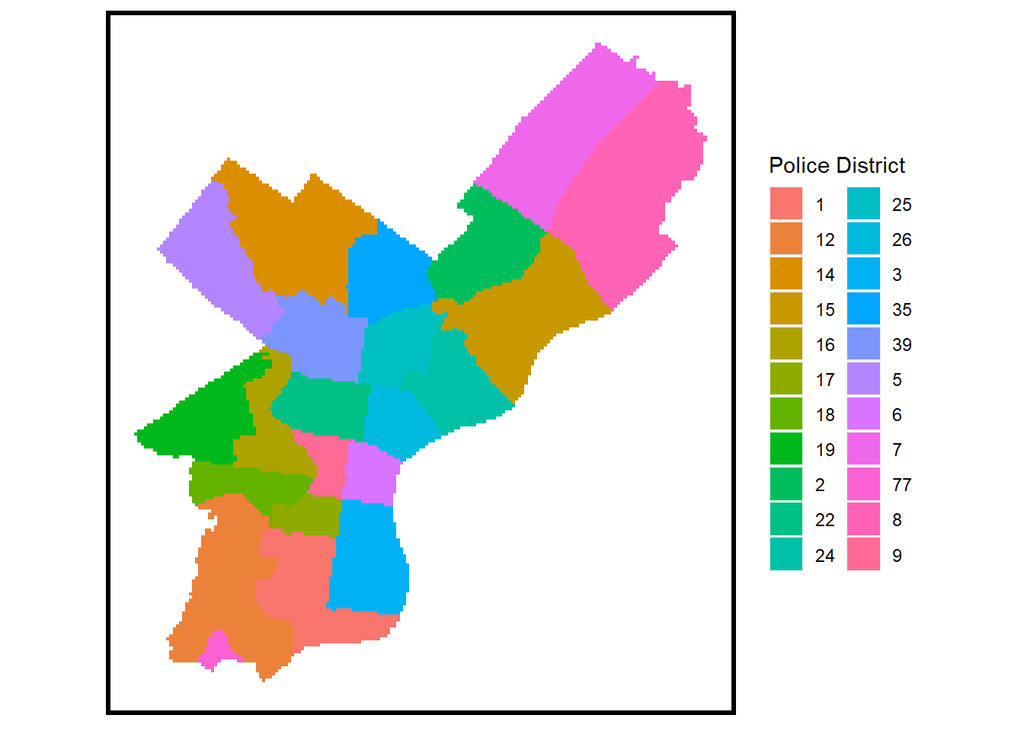

```r
ggplot(final_net)+
  geom_sf(aes(fill = `Police District`), color = NA)+
  mapTheme()+
  labs()
```

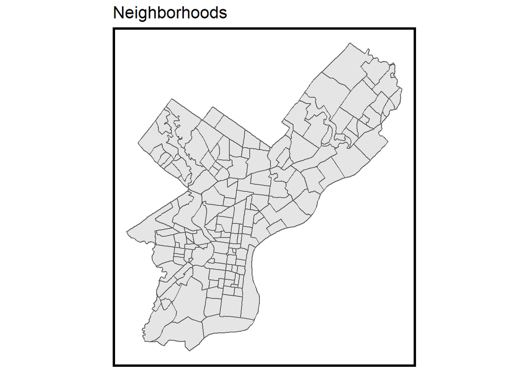

```r
ggplot(nhoods)+
  geom_sf()+
  mapTheme()+
  labs(title = 'Neighborhoods')
```

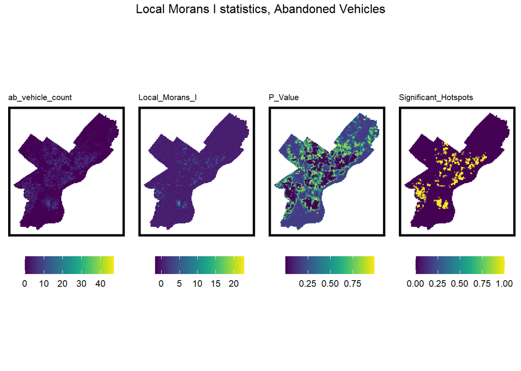

```r
final_net.nb <- poly2nb(as_Spatial(final_net), queen=TRUE)
final_net.weights <- nb2listw(final_net.nb, style="W", zero.policy=TRUE)

final_net.localMorans <-
  cbind(
    as.data.frame(localmoran(final_net$abandoned_vehicles, final_net.weights)),
    as.data.frame(final_net)) %>%
  st_sf() %>%
  dplyr::select(ab_vehicle_count = abandoned_vehicles,
                Local_Morans_I = Ii,
                P_Value = `Pr(z != E(Ii))`) %>%
  mutate(Significant_Hotspots = ifelse(P_Value <= 0.005, 1, 0)) %>%
  gather(Variable, Value, -geometry)

vars <- unique(final_net.localMorans$Variable)
varList <- list()

for(i in vars){
  varList[[i]] <-
    ggplot() +
    geom_sf(data = filter(final_net.localMorans, Variable == i),
            aes(fill = Value), colour=NA) +
    scale_fill_viridis(name="") +
    labs(title=i) +
    mapTheme() + theme(legend.position="bottom", plot.title = element_text(size=8))}

do.call(grid.arrange,c(varList, ncol = 4, top = "Local Morans I statistics, Abandoned Vehicles"))
```

By running Local Moran’s I tests of our dependent variables see highly significant clustering of abandoned vehicles in many neighborhoods in Philly.

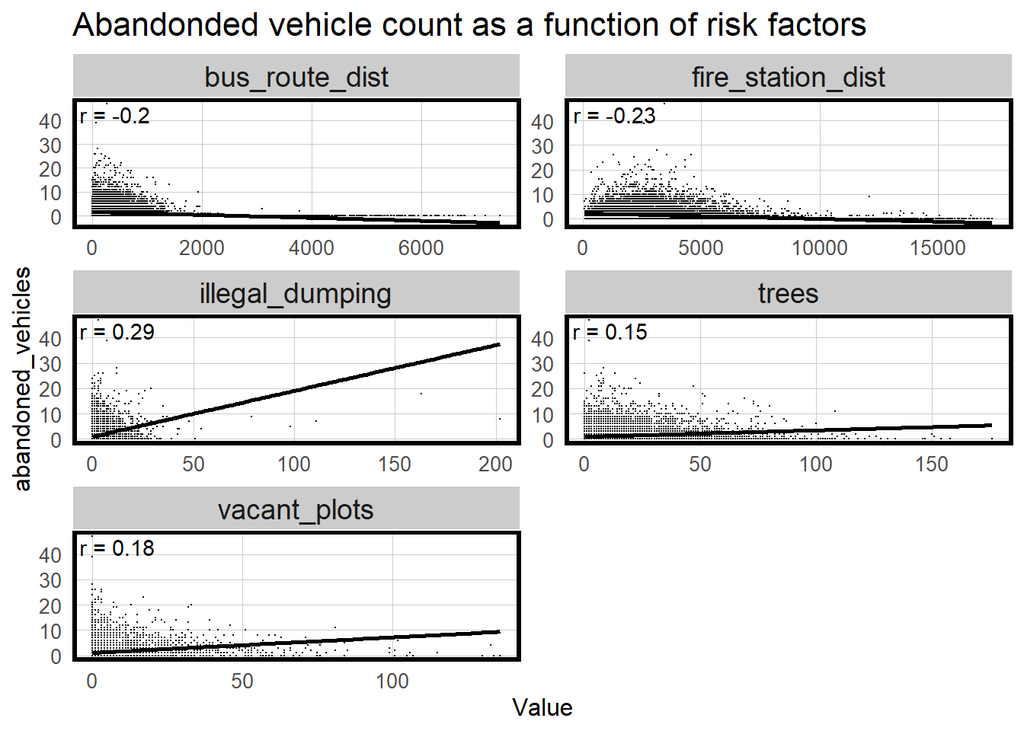

```r
correlation.long <-
  st_drop_geometry(final_net) %>%
  dplyr::select(-uniqueID, -`Police District`, -NAME, -cvID) %>%
  gather(Variable, Value, -abandoned_vehicles)

correlation.cor <-
  correlation.long %>%
  group_by(Variable) %>%
  summarize(correlation = cor(Value, abandoned_vehicles, use = "complete.obs"))

ggplot(correlation.long, aes(Value, abandoned_vehicles)) +
  geom_point(size = 0.1) +
  geom_text(data = correlation.cor, aes(label = paste("r =", round(correlation, 2))),
            x=-Inf, y=Inf, vjust = 1.5, hjust = -.1) +
  geom_smooth(method = "lm", se = FALSE, colour = "black") +
  facet_wrap(~Variable, ncol = 2, scales = "free") +
  labs(title = "Abandonded vehicle count as a function of risk factors") +
  plotTheme()
```

Most of our correlations coefficients have an absolute value of around 0.2. The variable with the largest correlation is Illegal Dumping, which makes sense considering it is from the same data set as Abandoned Vehicles and tracks a similar behavior.

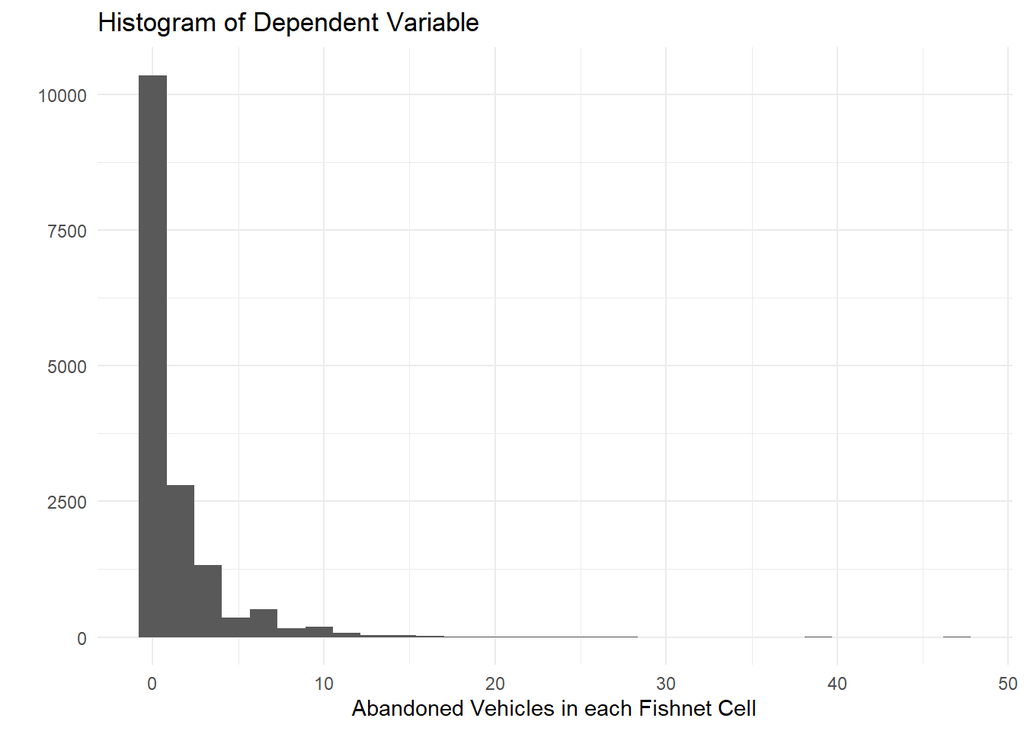

```r
ggplot(final_net)+
  geom_histogram(aes(x = abandoned_vehicles))+
  theme_minimal()+
  labs(title = 'Histogram of Dependent Variable' , y = '' , x = 'Abandoned Vehicles in each Fishnet Cell')
```

The dependent variable follows a Poisson distribution

```r
### random cv


reg.vars <- colnames(final_net)[!colnames(final_net) %in% c('uniqueID', 'Police District','geometry', 'abandoned_vehicles', 'cvID', 'NAME')]

#reg1 illdumps
reg.out1.nhood <- crossValidate(
  dataset = final_net,
  id = "NAME",
  dependentVariable = "abandoned_vehicles",
  indVariables = c('illegal_dumping')) %>%
  dplyr::select(cvID = NAME, abandoned_vehicles, Prediction, geometry) %>%
  mutate(Error = Prediction - abandoned_vehicles,
         Regression = 'Neighborhood Grouping')

reg.out1.nhood.table <- reg.out1.nhood %>% group_by(cvID) %>%
  summarize(Mean_Error = mean(Error), na.rm = T,
            MAE = mean(abs(Mean_Error)), na.rm = T,
            SD_MAE = mean(abs(Mean_Error), na.rm = T))

#reg1 illdumps
reg.out1.pd <- crossValidate(
  dataset = final_net,
  id = "Police District",
  dependentVariable = "abandoned_vehicles",
  indVariables = c('illegal_dumping')) %>%
  dplyr::select(cvID = `Police District`, abandoned_vehicles, Prediction, geometry) %>%
  mutate(Error = Prediction - abandoned_vehicles,
         Regression = 'Police District Grouping')

reg.out1.pd.table <- reg.out1.pd %>% group_by(cvID) %>%
  summarize(Mean_Error = mean(Error), na.rm = T,
            MAE = mean(abs(Mean_Error)), na.rm = T,
            SD_MAE = mean(abs(Mean_Error), na.rm = T))


#reg1cv  illdumps
reg.out1cv <- crossValidate(
  dataset = final_net,
  id = "cvID",
  dependentVariable = "abandoned_vehicles",
  indVariables = c('illegal_dumping')) %>%
  dplyr::select(cvID = cvID, abandoned_vehicles, Prediction, geometry) %>%
  mutate(Error = Prediction - abandoned_vehicles,
         Regression = 'Abandonded Vehicles ~ Illegal Dumping')

reg.out1cv.table <- reg.out1cv %>% group_by(cvID) %>%
  summarize(Mean_Error = mean(Error), na.rm = T,
            MAE = mean(abs(Mean_Error)), na.rm = T,
            SD_MAE = mean(abs(Mean_Error), na.rm = T))


#reg2 illdumps and vacant plots
reg.out2 <- crossValidate(
  dataset = final_net,
  id = 'cvID',
  dependentVariable = "abandoned_vehicles",
  indVariables = c('illegal_dumping', 'vacant_plots')) %>%
  dplyr::select(cvID = `cvID`, abandoned_vehicles, Prediction, geometry) %>%
  mutate(Error = Prediction - abandoned_vehicles,
         Regression = 'Abandonded Vehicles ~ Illegal Dumping + Vacant lots')

reg.out2.table <- reg.out2 %>% group_by(cvID) %>%
  summarize(Mean_Error = mean(Error), na.rm = T,
            MAE = mean(abs(Mean_Error)), na.rm = T,
            SD_MAE = mean(abs(Mean_Error), na.rm = T))

#reg3 illdumps and trees
reg.out3 <- crossValidate(
  dataset = final_net,
  id = "cvID",
  dependentVariable = "abandoned_vehicles",
  indVariables = c('illegal_dumping', 'trees')) %>%
  dplyr::select(cvID = `cvID`, abandoned_vehicles, Prediction, geometry) %>%
  mutate(Error = Prediction - abandoned_vehicles,
         Regression ='Abandonded Vehicles ~ Illegal Dumping + Trees')

reg.out3.table <- reg.out3 %>% group_by(cvID) %>%
  summarize(Mean_Error = mean(Error), na.rm = T,
            MAE = mean(abs(Mean_Error)), na.rm = T,
            SD_MAE = mean(abs(Mean_Error), na.rm = T))

#reg4 illdumps and bus route dist
reg.out4 <- crossValidate(
  dataset = final_net,
  id = "cvID",
  dependentVariable = "abandoned_vehicles",
  indVariables = c('illegal_dumping', 'bus_route_dist')) %>%
  dplyr::select(cvID = `cvID`, abandoned_vehicles, Prediction, geometry) %>%
  mutate(Error = Prediction - abandoned_vehicles,
         Regression = 'Abandonded Vehicles ~ Illegal Dumping + Bus Route Distance')

reg.out4.table <- reg.out4 %>% group_by(cvID) %>%
  summarize(Mean_Error = mean(Error), na.rm = T,
            MAE = mean(abs(Mean_Error)), na.rm = T,
            SD_MAE = mean(abs(Mean_Error), na.rm = T))

#reg4 illdumps and bus route dist
reg.out5 <- crossValidate(
  dataset = final_net,
  id = "cvID",
  dependentVariable = "abandoned_vehicles",
  indVariables = c('illegal_dumping', 'fire_station_dist')) %>%
  dplyr::select(cvID = `cvID`, abandoned_vehicles, Prediction, geometry) %>%
  mutate(Error = Prediction - abandoned_vehicles,
         Regression = 'Abandonded Vehicles ~ Illegal Dumping + Fire Station Distance')

reg.out5.table <- reg.out5 %>% group_by(cvID) %>%
  summarize(Mean_Error = mean(Error), na.rm = T,
            MAE = mean(abs(Mean_Error)), na.rm = T,
            SD_MAE = mean(abs(Mean_Error), na.rm = T))



reg.out.all <- crossValidate(
  dataset = final_net,
  id = "cvID",
  dependentVariable = "abandoned_vehicles",
  indVariables = reg.vars) %>%
  dplyr::select(cvID = `cvID`, abandoned_vehicles, Prediction, geometry) %>%
  mutate(Error = Prediction - abandoned_vehicles,
         Regression = 'All Variables')

reg.out.all.table <- reg.out.all %>% group_by(cvID) %>%
  summarize(Mean_Error = mean(Error), na.rm = T,
            MAE = mean(abs(Mean_Error)), na.rm = T,
            SD_MAE = mean(abs(Mean_Error), na.rm = T))

reg.out.all.nhood <- crossValidate(
  dataset = final_net,
  id = "NAME",
  dependentVariable = "abandoned_vehicles",
  indVariables = reg.vars) %>%
  dplyr::select(cvID = `NAME`, abandoned_vehicles, Prediction, geometry) %>%
  mutate(Error = Prediction - abandoned_vehicles,
         Regression = 'All Variables - Neighborhood LOGO')

reg.out.all.nhood.table <- reg.out.all %>% group_by(cvID) %>%
  summarize(Mean_Error = mean(Error), na.rm = T,
            MAE = mean(abs(Mean_Error)), na.rm = T,
            SD_MAE = mean(abs(Mean_Error), na.rm = T))

reg.summary <-
  rbind(reg.out1.nhood, reg.out1.pd , reg.out1cv, reg.out2, reg.out3,reg.out4,reg.out5,reg.out.all,reg.out.all.nhood) %>%
    st_sf()
```

To build my model, I started only regressing Abandoned Vehicles on Illegal Dumping, which resulted with a MAE of 0.25, indicating on average, the error between the predicted amount of Abandoned Vehicles and the actual amount in each grid cell is 0.25. As I iteratively added more predictors, each added little accuracy, dropping MAE by 0.01. When I combined all variables, MAE decreases to 0.22. As the average amount of Abandoned Vehicles in each cell is 1.21, this amount of error is substantial.

It makes sense that Illegal Dumping is the most predictive risk factor, as they are from the same data set and are a similar phenomenon to Abandoned Vehicles. However, I am hesitant to draw more risk factors from the Philly311 data set as they will be subject to the same biases as these variables.

Using spatial LOGO cross validation, for both neighborhood and police district grouping resulted in higher MAE’s, suprisingly.

```r
error_by_reg_and_fold <-
  reg.summary %>%
    group_by(Regression, cvID) %>%
    summarize(Mean_Error = mean(Prediction - abandoned_vehicles, na.rm = T),
              MAE = mean(abs(Mean_Error), na.rm = T),
              SD_MAE = mean(abs(Mean_Error), na.rm = T)) %>%
  ungroup()

error_by_reg_and_fold %>%
  st_drop_geometry() %>%
  group_by(Regression) %>%
  summarize(Mean_MAE = round(mean(MAE), 2),
            SD_MAE = round(sd(MAE), 2)) %>%
  kable() %>%
  kable_styling("striped", full_width = F) %>%
  group_rows("Random k-fold CV", 1,6) %>%
  group_rows("Spatial LOGO CV", 7,9)
```

| Regression | Mean_MAE | SD_MAE |
| --- | --- | --- |
| **Random k-fold CV** |  |  |
| Abandonded Vehicles ~ Illegal Dumping | 0.25 | 0.52 |
| Abandonded Vehicles ~ Illegal Dumping + Bus Route Distance | 0.24 | 0.35 |
| Abandonded Vehicles ~ Illegal Dumping + Fire Station Distance | 0.23 | 0.37 |
| Abandonded Vehicles ~ Illegal Dumping + Trees | 0.24 | 0.36 |
| Abandonded Vehicles ~ Illegal Dumping + Vacant lots | 0.24 | 0.41 |
| All Variables | 0.22 | 0.23 |
| **Spatial LOGO CV** |  |  |
| All Variables - Neighborhood LOGO | 1.36 | 4.64 |
| Neighborhood Grouping | 5.45 | 54.26 |
| Police District Grouping | 1.49 | 3.69 |

```r
tracts18 <-
  get_acs(geography = "tract", variables = c("B01001_001E","B01001A_001E"),
          year = 2018, state='PA', county='Philadelphia', geometry=T, progress_bar = FALSE) %>%
  st_transform(2272)  %>%
  dplyr::select(variable, estimate, GEOID) %>%
  spread(variable, estimate) %>%
  rename(TotalPop = B01001_001,
         NumberWhites = B01001A_001) %>%
  mutate(percentWhite = NumberWhites / TotalPop,
         raceContext = ifelse(percentWhite > .5, "Majority_White", "Majority_Non_White")) %>%
  .[nhoods,]

reg.summary %>%
  filter(str_detect(Regression, "All")) %>%
  st_centroid() %>%
  st_join(tracts18) %>%
  na.omit() %>%
  st_drop_geometry() %>%
  group_by(Regression, raceContext) %>%
  summarize(mean.Error = mean(Error, na.rm = T)) %>%
  spread(raceContext, mean.Error) %>%
  kable(caption = "Mean Error by neighborhood racial context") %>%
  kable_styling("striped", full_width = F)
```

[output not shown]

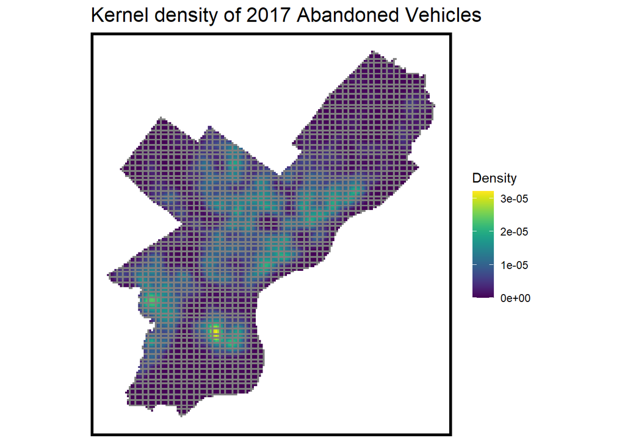

```r
ab2018 <- abandonedsf %>% filter(year == 2018) %>% mutate(Legend = 'abandoned_vehicles') %>% dplyr::select(Legend)

abv_ppp <- as.ppp(st_coordinates(ab2017), W = st_bbox(final_net))
abv_KD <- spatstat.core::density.ppp(abv_ppp, 1000)

as.data.frame(abv_KD) %>%
  st_as_sf(coords = c("x", "y"), crs = st_crs(final_net)) %>%
  aggregate(., final_net, mean) %>%
   ggplot() +
     geom_sf(aes(fill=value), color = NA) +
     #geom_sf(data = sample_n(burglaries, 1500), size = .5) +
     scale_fill_viridis(name = "Density") +
     labs(title = "Kernel density of 2017 Abandoned Vehicles") +
     mapTheme()
```

[figure not shown]

```r
abv_KDE_sf <- as.data.frame(abv_KD) %>%
  st_as_sf(coords = c("x", "y"), crs = st_crs(final_net)) %>%
  aggregate(., final_net, mean) %>%
  mutate(label = "Kernel Density",
         Risk_Category = ntile(value, 100),
         Risk_Category = case_when(
           Risk_Category >= 90 ~ "90% to 100%",
           Risk_Category >= 70 & Risk_Category <= 89 ~ "70% to 89%",
           Risk_Category >= 50 & Risk_Category <= 69 ~ "50% to 69%",
           Risk_Category >= 30 & Risk_Category <= 49 ~ "30% to 49%",
           Risk_Category >= 1 & Risk_Category <= 29 ~ "1% to 29%"))%>%
  cbind(
    aggregate(
      dplyr::select(ab2018) %>% mutate(abvcount = 1), ., sum) %>%
    mutate(abvcount = replace_na(abvcount, 0))) %>%
  dplyr::select(label, Risk_Category, abvcount)




abv_risk_sf <-
  filter(reg.summary, Regression == "All Variables") %>%
  mutate(label = "Risk Predictions",
         Risk_Category = ntile(Prediction, 100),
         Risk_Category = case_when(
           Risk_Category >= 90 ~ "90% to 100%",
           Risk_Category >= 70 & Risk_Category <= 89 ~ "70% to 89%",
           Risk_Category >= 50 & Risk_Category <= 69 ~ "50% to 69%",
           Risk_Category >= 30 & Risk_Category <= 49 ~ "30% to 49%",
           Risk_Category >= 1 & Risk_Category <= 29 ~ "1% to 29%"))%>%
  cbind(
    aggregate(
      dplyr::select(ab2018) %>% mutate(abvcount = 1), ., sum) %>%
      mutate(abvcount= replace_na(abvcount, 0))) %>%
  dplyr::select(label,Risk_Category, abvcount)

rbind(abv_KDE_sf, abv_risk_sf) %>%
  na.omit() %>%
  gather(Variable, Value, -label, -Risk_Category, -geometry) %>%
  ggplot() +
    geom_sf(aes(fill = Risk_Category), colour = NA) +
   geom_sf(data = sample_n(ab2018, 3000), size = .5, colour = "black") +
    facet_wrap(~label, ) +
    scale_fill_viridis(discrete = TRUE) +
    labs(title="Comparison of Kernel Density and Risk Predictions",
         subtitle="2017 burglar risk predictions; 2018 burglaries") +
    mapTheme()
```

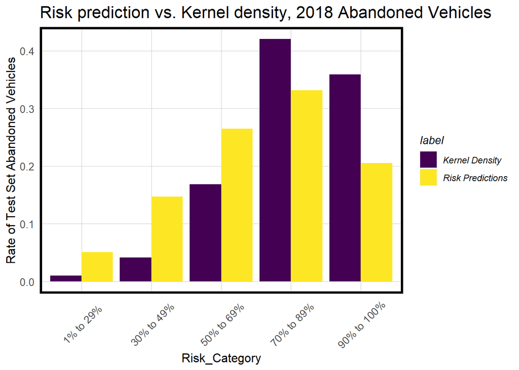

```r
rbind(abv_KDE_sf, abv_risk_sf)  %>%
  st_set_geometry(NULL) %>% na.omit() %>%
  gather(Variable, Value, -label, -Risk_Category) %>%
  group_by(label, Risk_Category) %>%
  summarize(countabv = sum(Value)) %>%
  ungroup() %>%
  group_by(label) %>%
  mutate(Rate_of_test_set_crimes = countabv / sum(countabv)) %>%
    ggplot(aes(Risk_Category,Rate_of_test_set_crimes)) +
      geom_bar(aes(fill=label), position="dodge", stat="identity") +
      scale_fill_viridis(discrete = TRUE) +
      labs(title = "Risk prediction vs. Kernel density, 2018 Abandoned Vehicles", y = 'Rate of Test Set Abandoned Vehicles') +
      plotTheme() + theme(axis.text.x = element_text(angle = 45, vjust = 0.5))
```

This bar graph compares the effectiveness of our risk prediction models to a business-as-usual kernel density approach. As the kernel density out predicts our model at the highest two risk levels, we unfortunately cannot say that our model is better than the normal approach.

**Conclusion**

While the model I created could allocate resources better than a random deployment, it does not out-predict the traditional kernel density approach, and thus I would not recommend it to be used to prevent vehicle abandonments. As a vehicle being abandoned is a fairly inconspicuous event, being able to catch perpetrators in the act is harder than for other crimes. The type of modeling done here could be helpful in placing surveillance cameras, but ultimate the best way to have abandoned vehicles reported is through community input.

Abandoned vehicles are nuisance to the neighborhoods they are in, and their timely removal is important. Being able to track where they will occur is important keeping the streets clean.